# 6.Composition

2025-02-28

# Purpose

Addressing these following questions found in Loop_2023_overview.RMD:

1. How much variation is there in microbial DNA in blood (composition)?
- Examining replicates of each fraction - do you see the same bacteria across subjects (if no, how do you interpret that.. could hint at heterogeneous.. caveat of how much blood do you need to be representative)
- Are fractions more similar to each other or to the patient?
- Looking at beta diversity; how close they cluster to each other
- Can test using distance matrices
2. Do certain taxa prefer certain compartments of blood?
- Beta diversity between fractions
- Identifying if there are different proportion of samples within each cluster
- Differential abundance (can only do if specific taxa are found across many samples)

# Libraries

```r
# BL_EDIT - Supressing warnings and fixing grammer
library(phyloseq)
library(ggplot2)
library(tidyverse)
library(kableExtra)
library(RColorBrewer)
library(speedyseq)
library(here)
library(microshades)
library(vegan)
library(patchwork)
library(ggpubr)
library(reshape2)
library(cowplot)
library("ggvenn")
options(dplyr.summarise.inform = FALSE)
```

```r
load(here("2024_code", "Loop_filt_ps_fixed.RData"))
```

# Sample overview

```r
meta_ps <- data.frame(ps@sam_data)

meta_nomc <- meta_ps %>%
  filter(fraction != "mock_community" & dnase == "no")
table(meta_nomc$fraction)
```

```
##
##     BF plasma    RBC     WB
##     12     12      8      5
```

```r
table(meta_nomc$disease, meta_nomc$fraction)
```

```
##
##                   BF plasma RBC WB
##   high-grade       5      5   3  2
##   low-grade        3      4   3  3
##   screen-negative  4      3   2  0
```

### Prop test

Are more samples removed from the screen-negative vs other disease groups? Could be interesting. Will be doing a proportion test and will do a Fischers exact test on it due to the small sample size.

```r
# disease
disease_prop <- data.frame(
  "screen_neg" = c(3, 2, 4, 0),
  "low-grade" = c(4, 3, 3, 3),
  "high-grade" = c(5, 3, 5, 2),
  row.names = c("plasma", "RBC", "BF", "WB"),
  stringsAsFactors = FALSE
)
colnames(disease_prop) <- c("screen_neg", "low-grade", "high-grade")

fisher.test(disease_prop)
```

```
##
##  Fisher's Exact Test for Count Data
##
## data:  disease_prop
## p-value = 0.8906
## alternative hypothesis: two.sided
```

```r
rm(disease_prop)
```

No association with health status and successfully sequenced sample.

# How many taxa present

```r
ps_nomc <- ps %>%
  subset_samples(., fraction != "mock_community") %>%
  subset_samples(., dnase == "no")
ps_nomc <- subset_taxa(ps_nomc, taxa_sums(ps_nomc) >0)

taxa_counts <- ps_nomc@tax_table %>% data.frame()

taxa_counts <- lapply(taxa_counts, unique)
taxa_counts <- lapply(taxa_counts, function(x) x[!is.na(x)]) # removing all NAs from each level

print(lengths(taxa_counts))
```

```
## Kingdom  Phylum   Class   Order  Family   Genus Species
##       1      10      14      39      67      82      69
```

The above code removes the NAs.

# Overview - Phylum

```r
ps_n <- transform_sample_counts(ps_nomc,function(x) 100* x/sum(x))
ps_n_phy <- tax_glom(ps_n, "Phylum")
ps_n_phy  <- subset_taxa(ps_n_phy, taxa_sums(ps_n_phy) >0)
mdf_phy <- psmelt(ps_n_phy)

summary_phylum <- mdf_phy %>%
        group_by(Phylum) %>%
        summarise(rank_abundance = sum(Abundance), mean_abundance = mean(Abundance), median_abundance = median(Abundance), min_abundance = min(Abundance), max_abundance = max(Abundance)) %>%
        arrange(desc(rank_abundance)) %>%
        mutate(order = row_number()) %>%
        ungroup()

head(summary_phylum)
```

| Phylum | rank_abundance | mean_abundance | median_abundance | min_abundance | max_abundance | order |
| --- | --- | --- | --- | --- | --- | --- |
| Firmicutes | 1588 | 42.9189189 | 44 | 0 | 100 | 1 |
| Proteobacteria | 1148 | 31.0270270 | 26 | 0 | 100 | 2 |
| Actinobacteriota | 528 | 14.2702703 | 2 | 0 | 98 | 3 |
| Bacteroidota | 398 | 10.7567568 | 0 | 0 | 98 | 4 |
| Acidobacteriota | 14 | 0.3783784 | 0 | 0 | 14 | 5 |
| Deinococcota | 10 | 0.2702703 | 0 | 0 | 10 | 6 |

### Plot

```r
color_dfs <- create_color_dfs(mdf_phy, selected_groups = c("Bacteroidota", "Actinobacteriota", "Proteobacteria", "Firmicutes"))


# reorder_samples_by will change the order of samples based on an abundance of a specified subgroup taxonomy
firm_order <- reorder_samples_by(color_dfs$mdf, color_dfs$cdf, order = "Firmicutes", group_level = "Phylum", sink_abundant_groups = FALSE)


# factor fractions
firm_order$mdf$fraction <- factor(firm_order$mdf$fraction, levels = c("plasma", "RBC", "BF", "WB"))

firm_legend <- custom_legend(firm_order$mdf, firm_order$cdf, subgroup_level = "Phylum", legend_orientation = "vertical")


plot <- plot_microshades(firm_order$mdf, firm_order$cdf, group_label = "Phylum", x = "Sample") +
  theme_bw() +
  theme(axis.text.x = element_blank(), legend.position = "none") +
  ylab("Relative Abundance") +
  facet_wrap(~fraction, scales = "free_x", nrow = 1)

Fig3a_opt1 <- plot + firm_legend

Fig3a_opt2 <- plot_grid(plot, firm_legend, rel_widths = c(2.5, 1), ncol = 2)
```

Just a fun overview at the phylum level. It looks like Firmicutes and Proteobacteria are the main phyla. This is sorted by Firmicutes abundance, so the fractions/patients are distributed throughout. The “unknown” is only a label, since typically a higher resolution is put there, butt his is only at the phylum level.

# Overview plot - Genus level

```r
ps_nomc_g <- ps_nomc %>%
  tax_glom(., "Genus", NArm = FALSE) %>%
  transform_sample_counts(., function(x) 100* x/sum(x))

ps_nomc_g  <- subset_taxa(ps_nomc_g, taxa_sums(ps_nomc_g) >0)

mdf <- psmelt(ps_nomc_g)

color_dfs <- create_color_dfs(mdf, selected_groups = c("Bacteroidota", "Actinobacteriota", "Proteobacteria", "Firmicutes"))


# reorder_samples_by will change the order of samples based on an abundance of a specified subgroup taxonomy
firm_order <- reorder_samples_by(color_dfs$mdf, color_dfs$cdf, order = "Firmicutes", group_level = "Phylum", subgroup_level = "Genus", sink_abundant_groups = FALSE)

firm_legend <-custom_legend(firm_order$mdf, firm_order$cdf, legend_orientation = "horizontal")


# factor fractions
firm_order$mdf$fraction <- factor(firm_order$mdf$fraction, levels = c("plasma", "RBC", "BF", "WB"))

plot <- plot_microshades(firm_order$mdf, firm_order$cdf, group_label = "Phylum-Genus", x = "Sample") +
  #theme_bw() +
  theme(legend.position = "none", axis.text.x = element_blank()) +
  facet_wrap(~fraction, scales = "free", nrow = 1) +
  ylab("Relative Abundance")

FigS4 <- plot / firm_legend
```

There is a lot of “other” making up the firmicutes sections.

# Overview plot - Species level

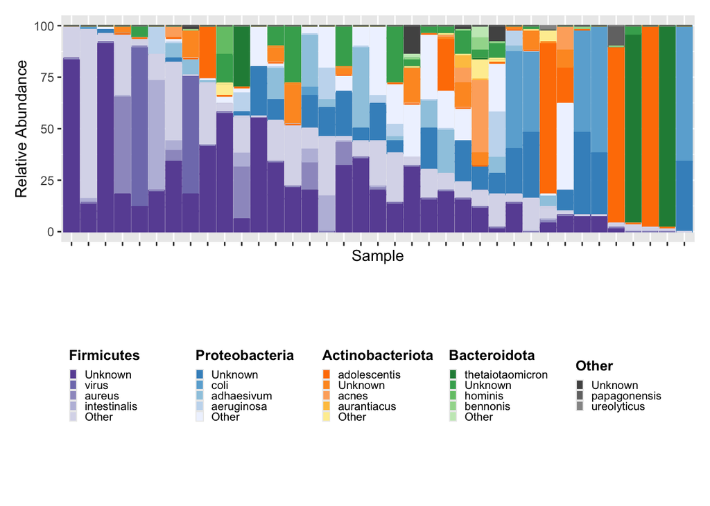

```r
ps_nomc_s <- ps_nomc %>%
  transform_sample_counts(., function(x) 100* x/sum(x))

ps_nomc_s  <- subset_taxa(ps_nomc_s, taxa_sums(ps_nomc_s) >0)

mdf <- psmelt(ps_nomc_s)

color_dfs <- create_color_dfs(mdf, group_level = "Phylum", subgroup_level = "Species", selected_groups = c("Bacteroidota", "Actinobacteriota", "Proteobacteria", "Firmicutes"))


# reorder_samples_by will change the order of samples based on an abundance of a specified subgroup taxonomy
firm_order <- reorder_samples_by(color_dfs$mdf, color_dfs$cdf, order = "Firmicutes", group_level = "Phylum", subgroup_level = "Species", sink_abundant_groups = FALSE)

firm_legend <-custom_legend(firm_order$mdf, firm_order$cdf, group_level = "Phylum", subgroup_level = "Species", legend_orientation = "horizontal")


# factor fractions
firm_order$mdf$fraction <- factor(firm_order$mdf$fraction, levels = c("plasma", "RBC", "BF", "WB"))

plot <- plot_microshades(firm_order$mdf, firm_order$cdf, group_label = "Phylum-Species") +
  xlab("Sample") +
  theme(legend.position = "none", axis.text.x = element_blank()) +
  ylab("Relative Abundance")

plot / firm_legend
```

There are a lot of unknowns when it comes to the species level. I think we should continue our analysis at the Genus level instead.

# Top Species

```r
ps_nomc <- ps %>%
  subset_samples(., fraction != "mock_community") %>%
  subset_samples(., dnase == "no")
ps_nomc <- subset_taxa(ps_nomc, taxa_sums(ps_nomc) >0)
meta_nomc <- data.frame(ps_nomc@sam_data)

# Calculate taxa sum of the selected samples
top_all_s <- head(sort(colSums(otu_table(ps_nomc)), decreasing = TRUE), 10)

# Combine count and taxonomyTable
top_all_s <- cbind(as.data.frame(tax_table(ps_nomc)[names(top_all_s),]), Count = top_all_s)

head(top_all_s$Species)
```

```
## [1] "adolescentis"     "coli"             "thetaiotaomicron" NA
## [5] NA                 "adhaesivum"
```

# Top Genera

```r
ps_nomc_g <- ps_nomc %>%
  tax_glom(., "Genus", NArm = FALSE)
ps_nomc_g <- subset_taxa(ps_nomc_g, taxa_sums(ps_nomc_g)>0)


# Calculate taxa sum of the selected samples
top_all <- head(sort(colSums(otu_table(ps_nomc_g)), decreasing = TRUE), 10)

# Combine count and taxonomyTable
top_all <- cbind(as.data.frame(tax_table(ps_nomc_g)[names(top_all),]), Count = top_all)

head(top_all$Genus)
```

```
## [1] "Escherichia-Shigella" "Bacillus"             "Bifidobacterium"
## [4] "Bacteroides"          "Alteribacillus"       "Pseudomonas"
```

# Heatmap

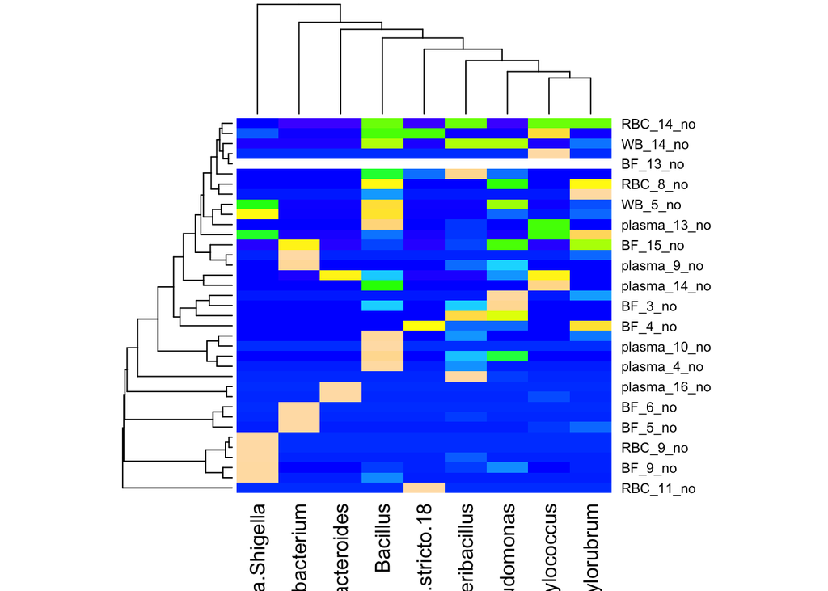

```r
ps_nomc <- ps %>%
  subset_samples(., fraction != "mock_community") %>%
  subset_samples(., dnase == "no") %>%
  tax_glom(., "Genus")
ps_nomc <- subset_taxa(ps_nomc, taxa_sums(ps_nomc) >0)
ps_nomc_rel <- transform_sample_counts(ps_nomc, function(x) 100* x/sum(x))

ps_nomc_df <- psmelt(ps_nomc_rel)

hm_df <- ps_nomc_df %>%
  select(sam_names, Genus, Abundance) %>%
  filter(Genus %in% top_all$Genus) %>%
  pivot_wider(., id_cols = sam_names, names_from = Genus,  values_from = Abundance) %>%
  data.frame()

rownames(hm_df) <- hm_df$sam_names
hm_df <- hm_df[-1]

hm_test <- as.matrix(hm_df, rownames = TRUE)

heatmap(hm_test, Colv = TRUE, col = topo.colors(256))
```

## Bubble plot - Genus

I blasted the sequence that is NA and it maps to virgibacillus

```r
ps_nomc <- ps %>%
  subset_samples(., fraction != "mock_community") %>%
  subset_samples(., dnase == "no") %>%
  tax_glom(., "Genus", NArm = FALSE)
ps_nomc <- subset_taxa(ps_nomc, taxa_sums(ps_nomc) >0)
ps_nomc_rel <- transform_sample_counts(ps_nomc, function(x) 100* x/sum(x))

ps_nomc_df <- psmelt(ps_nomc_rel)


hm_df <- ps_nomc_df %>%
  select(sam_names, Genus, Abundance, fraction) %>%
  filter(Genus %in% top_all$Genus) %>%
  data.frame()

hm_df$fraction <- factor(hm_df$fraction, levels = c("plasma", "RBC", "BF", "WB"))
hm_df$Genus[hm_df$Genus == "Clostridium sensu stricto 18"] <- "Clostridium"
hm_df$Genus[hm_df$Genus == "Methylobacterium-Methylorubrum"] <- "Methylobacterium \nMethylorubrum"

bubble_plot <- ggplot(hm_df, aes(x = sam_names, y = Genus)) +
  geom_point(aes(size = Abundance, fill = Genus), alpha = 0.75, shape = 21) +
  facet_wrap(~fraction, scales = "free_x", nrow = 1) +
  scale_size_continuous(limits = c(0.1, 100), range = c(1,17), breaks = c(1,25,50,75)) + labs( x= "Sample", y = "", size = "Relative \nAbundance (%)", fill = "") +
  guides(fill = "none") +
  theme(legend.key=element_blank(),
  axis.text.x = element_blank(),
  panel.background = element_blank(), panel.border = element_rect(colour = "black", fill = NA),
  legend.position = "right")


Fig3b <- bubble_plot
```

I blasted the NA sequence and it maps to virgibacillus - which has been isolated from stool samples from both children and adults.

# Clean-up

```r
keep <- c("ps_r50", "meta_ps", "ps", "Fig3a_opt2", "Fig3a_opt1", "Fig3b", "ps_nomc", "ps_nomc_rel")
rm(list=setdiff(ls(), keep))
```

Note that ps_nomc is agglomerated at the genus level.

# Variation in fraction

## Plasma - top genera

```r
ps_p <- ps_nomc_rel %>%
  subset_samples(., fraction == "plasma")

ps_p <- subset_taxa(ps_p, taxa_sums(ps_p) >0)


# Calculate taxa sum of the selected samples
top5 <- head(sort(colSums(otu_table(ps_p)), decreasing = TRUE), 10)

# Combine count and taxonomyTable
top5 <- cbind(as.data.frame(tax_table(ps_p)[names(top5),]), Count = top5)
head(top5$Genus)
```

```
## [1] "Bacillus"             "Escherichia-Shigella" "Bacteroides"
## [4] "Staphylococcus"       "Veillonella"          "Flavobacterium"
```

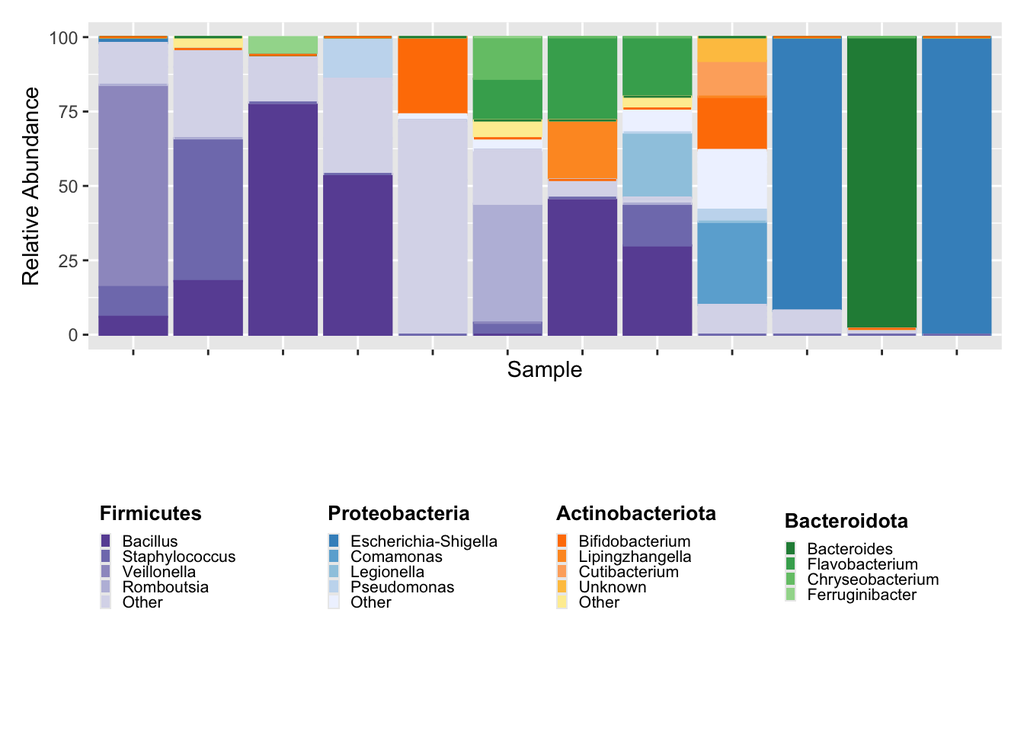

```r
mdf <- psmelt(ps_p)

color_dfs <- create_color_dfs(mdf, selected_groups = c("Bacteroidota", "Actinobacteriota", "Proteobacteria", "Firmicutes"))


# reorder_samples_by will change the order of samples based on an abundance of a specified subgroup taxonomy
firm_order <- reorder_samples_by(color_dfs$mdf, color_dfs$cdf, order = "Firmicutes", group_level = "Phylum", subgroup_level = "Genus", sink_abundant_groups = FALSE)

firm_legend <-custom_legend(firm_order$mdf, firm_order$cdf, legend_orientation = "horizontal")


# factor fractions
firm_order$mdf$fraction <- factor(firm_order$mdf$fraction, levels = c("plasma", "RBC", "BF", "WB"))

plot <- plot_microshades(firm_order$mdf, firm_order$cdf, group_label = "Phylum-Genus", x = "Sample") +
  ylab("Relative Abundance") +
  theme(legend.position = "none", axis.text.x = element_blank())

plot / firm_legend
```

2/3 of the samples look dominated by Firmicutes.

## RBC - top genera

```r
ps_rbc <- ps_nomc_rel %>%
  subset_samples(., fraction == "RBC")

ps_rbc <- subset_taxa(ps_rbc, taxa_sums(ps_rbc) >0)


# Calculate taxa sum of the selected samples
top5 <- head(sort(colSums(otu_table(ps_rbc)), decreasing = TRUE), 10)

# Combine count and taxonomyTable
top5 <- cbind(as.data.frame(tax_table(ps_rbc)[names(top5),]), Count = top5)
head(top5$Genus)
```

```
## [1] "Escherichia-Shigella"           "Clostridium sensu stricto 18"
## [3] "Bacteroides"                    "Methylobacterium-Methylorubrum"
## [5] "Bacillus"                       "Streptococcus"
```

## BF - top genera

```r
ps_bf <- ps_nomc_rel %>%
  subset_samples(., fraction == "BF")

ps_bf <- subset_taxa(ps_bf, taxa_sums(ps_bf) >0)

# Calculate taxa sum of the selected samples
top5 <- head(sort(colSums(otu_table(ps_bf)), decreasing = TRUE), 10)

# Combine count and taxonomyTable
top5 <- cbind(as.data.frame(tax_table(ps_bf)[names(top5),]), Count = top5)
head(top5$Genus)
```

```
## [1] "Bifidobacterium"                "Pseudomonas"
## [3] "Bacillus"                       "Methylobacterium-Methylorubrum"
## [5] "Escherichia-Shigella"           "Alteribacillus"
```

## WB - top genera

```r
ps_wb <- ps_nomc_rel %>%
  subset_samples(., fraction == "BF")

ps_wb <- subset_taxa(ps_wb, taxa_sums(ps_wb) >0)

# Calculate taxa sum of the selected samples
top5 <- head(sort(colSums(otu_table(ps_wb)), decreasing = TRUE), 10)

# Combine count and taxonomyTable
top5 <- cbind(as.data.frame(tax_table(ps_wb)[names(top5),]), Count = top5)
head(top5$Genus)
```

```
## [1] "Bifidobacterium"                "Pseudomonas"
## [3] "Bacillus"                       "Methylobacterium-Methylorubrum"
## [5] "Escherichia-Shigella"           "Alteribacillus"
```

# Comparing top genera by relative abundance

```r
ps_melt <- psmelt(ps_nomc_rel) #at the genus level

summary_genus <- ps_melt %>%
        group_by(Genus, fraction, OTU) %>%
        summarise(Abundance = Abundance, rank_abundance = sum(Abundance), mean_abundance = mean(Abundance), median_abundance = median(Abundance), min_abundance = min(Abundance), max_abundance = max(Abundance)) %>%
        arrange(desc(rank_abundance)) %>%
        mutate(order = row_number())

# Escherichia
ps_melt <- psmelt(ps_nomc_rel) %>% filter(Genus == "Escherichia-Shigella")
kruskal.test(ps_melt$Abundance ~ ps_melt$fraction)
```

```
##
##  Kruskal-Wallis rank sum test
##
## data:  ps_melt$Abundance by ps_melt$fraction
## Kruskal-Wallis chi-squared = 2.5753, df = 3, p-value = 0.4618
```

```r
# no significant differences

# Bacillus
ps_melt <- psmelt(ps_nomc_rel) %>% filter(Genus == "Bacillus")
kruskal.test(ps_melt$Abundance ~ ps_melt$fraction)
```

```
##
##  Kruskal-Wallis rank sum test
##
## data:  ps_melt$Abundance by ps_melt$fraction
## Kruskal-Wallis chi-squared = 1.9546, df = 3, p-value = 0.5819
```

```r
# no dif


# Bifidobacterium
ps_melt <- psmelt(ps_nomc_rel) %>% filter(Genus == "Bifidobacterium")
kruskal.test(ps_melt$Abundance ~ ps_melt$fraction)
```

```
##
##  Kruskal-Wallis rank sum test
##
## data:  ps_melt$Abundance by ps_melt$fraction
## Kruskal-Wallis chi-squared = 5.4086, df = 3, p-value = 0.1442
```

```r
# no dif

# Bacteroides
ps_melt <- psmelt(ps_nomc_rel) %>% filter(Genus == "Bacteroides")
kruskal.test(ps_melt$Abundance ~ ps_melt$fraction)
```

```
##
##  Kruskal-Wallis rank sum test
##
## data:  ps_melt$Abundance by ps_melt$fraction
## Kruskal-Wallis chi-squared = 0.63736, df = 3, p-value = 0.8878
```

```r
# no sig


# Alteribacillus
ps_melt <- psmelt(ps_nomc_rel) %>% filter(Genus == "Alteribacillus")
kruskal.test(ps_melt$Abundance ~ ps_melt$fraction)
```

```
##
##  Kruskal-Wallis rank sum test
##
## data:  ps_melt$Abundance by ps_melt$fraction
## Kruskal-Wallis chi-squared = 3.7563, df = 3, p-value = 0.289
```

```r
# no sig


# Pseudomonas
ps_melt <- psmelt(ps_nomc_rel) %>% filter(Genus == "Pseudomonas")
kruskal.test(ps_melt$Abundance ~ ps_melt$fraction) # significantly associated
```

```
##
##  Kruskal-Wallis rank sum test
##
## data:  ps_melt$Abundance by ps_melt$fraction
## Kruskal-Wallis chi-squared = 11.334, df = 3, p-value = 0.01005
```

```r
# 0.01

pairwise.wilcox.test(ps_melt$Abundance, ps_melt$fraction, p.adjust.method = "fdr")
```

```
##
##  Pairwise comparisons using Wilcoxon rank sum test with continuity correction
##
## data:  ps_melt$Abundance and ps_melt$fraction
##
##        BF    plasma RBC
## plasma 0.052 -      -
## RBC    0.067 0.873  -
## WB     0.873 0.039  0.040
##
## P value adjustment method: fdr
```

```r
# differences between plasma and WB; RBC and WB; trend with plasma and BF and RBC and BF


# Bacteroides
ps_melt <- psmelt(ps_nomc_rel) %>% filter(Genus == "Bacteroides")
kruskal.test(ps_melt$Abundance ~ ps_melt$fraction)
```

```
##
##  Kruskal-Wallis rank sum test
##
## data:  ps_melt$Abundance by ps_melt$fraction
## Kruskal-Wallis chi-squared = 0.63736, df = 3, p-value = 0.8878
```

```r
# no sig assoc.


# Alteribacillus
ps_melt <- psmelt(ps_nomc_rel) %>% filter(Genus == "Alteribacillus")
kruskal.test(ps_melt$Abundance ~ ps_melt$fraction)
```

```
##
##  Kruskal-Wallis rank sum test
##
## data:  ps_melt$Abundance by ps_melt$fraction
## Kruskal-Wallis chi-squared = 3.7563, df = 3, p-value = 0.289
```

```r
# no sig assoc.


# Methylobacterium-Methylorubrum
ps_melt <- psmelt(ps_nomc_rel) %>% filter(Genus == "Methylobacterium-Methylorubrum")
kruskal.test(ps_melt$Abundance ~ ps_melt$fraction)
```

```
##
##  Kruskal-Wallis rank sum test
##
## data:  ps_melt$Abundance by ps_melt$fraction
## Kruskal-Wallis chi-squared = 8.0862, df = 3, p-value = 0.04426
```

```r
pairwise.wilcox.test(ps_melt$Abundance, ps_melt$fraction, p.adjust.method = "fdr")
```

```
##
##  Pairwise comparisons using Wilcoxon rank sum test with continuity correction
##
## data:  ps_melt$Abundance and ps_melt$fraction
##
##        BF    plasma RBC
## plasma 0.053 -      -
## RBC    0.903 0.059  -
## WB     0.746 0.059  0.746
##
## P value adjustment method: fdr
```

```r
# p = 0.04, many trends between plasma and RBC, BF, and WB (p = 0.05)


# Clostridium
ps_melt <- psmelt(ps_nomc_rel) %>% filter(Genus == "Clostridium sensu stricto 18")
kruskal.test(ps_melt$Abundance ~ ps_melt$fraction)
```

```
##
##  Kruskal-Wallis rank sum test
##
## data:  ps_melt$Abundance by ps_melt$fraction
## Kruskal-Wallis chi-squared = 0.4501, df = 3, p-value = 0.9297
```

```r
# no significant association


# Virgibacillus (which is currently NA)
ps_melt <- psmelt(ps_nomc_rel) %>% filter(OTU == "TCAGGACGAACGCTGGCGGCGTGCCTAATACATGCAAGTCGCGCGCGGGAAGCAGGCTGA…")
kruskal.test(ps_melt$Abundance ~ ps_melt$fraction)
```

```
##
##  Kruskal-Wallis rank sum test
##
## data:  ps_melt$Abundance by ps_melt$fraction
## Kruskal-Wallis chi-squared = 2.7319, df = 3, p-value = 0.4348
```

```r
#not significant
```

### Pseudomonas!

```r
summary_genus$fraction <- factor(summary_genus$fraction, levels = c("plasma", "RBC", "BF", "WB"))

plot <- summary_genus %>%
  filter(Genus == "Pseudomonas") %>%
  ggplot(., aes(x = fraction, y = Abundance)) +
  geom_boxplot() +
  geom_point() +
  theme_bw()


## test

ps_melt <- psmelt(ps_nomc_rel) %>% filter(Genus == "Pseudomonas")

stat.test <- compare_means(Abundance ~ fraction, data = ps_melt,  method = "wilcox.test", p.adjust.method = "fdr")

Fig3C <- plot + stat_pvalue_manual(stat.test, label = "p.adj", y.position = c(32, 39), hide.ns = TRUE)
```

# Alpha diversity

```r
# adding pielou's evenness to the rest of the standard alpha div measures to our meta_ps object
meta_ps <- meta_ps %>%
  mutate(estimate_richness(ps, measures = c("Observed", "Shannon", "InvSimpson"))) %>%
  mutate(microbiome::evenness(ps, "pielou"))

sample_data(ps) <- meta_ps


meta_ps_long <- melt(meta_ps) %>% filter(variable %in% c("Shannon", "Observed", "pielou", "InvSimpson"))
```

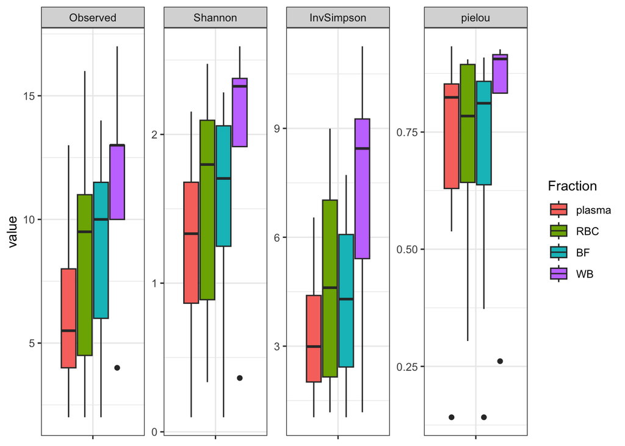

```r
meta_ps_long$fraction <- factor(meta_ps_long$fraction, levels = c("plasma", "RBC", "BF", "WB","mock_community"))

FigS5 <- meta_ps_long %>%
  filter(fraction != "mock_community" & dnase == "no") %>%
  ggplot(., aes(x = variable, y = value, fill = fraction)) +
  geom_boxplot() +
  facet_wrap(~variable, scales = "free", nrow = 1) +
  theme_bw() +
  theme(axis.title.x = element_blank(), axis.text.x = element_blank()) +
  guides(fill=guide_legend(title="Fraction"))

FigS5
```

```r
# BL_EDIT formatting is diff from supplement
```

### Stats

```r
# Checking normality
shapiro.test(meta_ps$Observed)
```

```
##
##  Shapiro-Wilk normality test
##
## data:  meta_ps$Observed
## W = 0.94951, p-value = 0.006336
```

```r
shapiro.test(meta_ps$Shannon)
```

```
##
##  Shapiro-Wilk normality test
##
## data:  meta_ps$Shannon
## W = 0.89926, p-value = 3.217e-05
```

```r
shapiro.test(meta_ps$InvSimpson)
```

```
##
##  Shapiro-Wilk normality test
##
## data:  meta_ps$InvSimpson
## W = 0.94001, p-value = 0.002066
```

```r
shapiro.test(meta_ps$pielou)
```

```
##
##  Shapiro-Wilk normality test
##
## data:  meta_ps$pielou
## W = 0.77574, p-value = 5.707e-09
```

```r
# all are non-normal


meta_sam <- meta_ps %>%
  filter(fraction != "mock_community" & dnase == "no")

# kruskal wallis test
kruskal.test(meta_sam$Observed ~ meta_sam$fraction)
```

```
##
##  Kruskal-Wallis rank sum test
##
## data:  meta_sam$Observed by meta_sam$fraction
## Kruskal-Wallis chi-squared = 6.1853, df = 3, p-value = 0.1029
```

```r
kruskal.test(meta_sam$Shannon ~ meta_sam$fraction)
```

```
##
##  Kruskal-Wallis rank sum test
##
## data:  meta_sam$Shannon by meta_sam$fraction
## Kruskal-Wallis chi-squared = 4.9366, df = 3, p-value = 0.1765
```

```r
kruskal.test(meta_sam$InvSimpson ~ meta_sam$fraction)
```

```
##
##  Kruskal-Wallis rank sum test
##
## data:  meta_sam$InvSimpson by meta_sam$fraction
## Kruskal-Wallis chi-squared = 4.4805, df = 3, p-value = 0.214
```

```r
kruskal.test(meta_sam$pielou ~ meta_sam$fraction)
```

```
##
##  Kruskal-Wallis rank sum test
##
## data:  meta_sam$pielou by meta_sam$fraction
## Kruskal-Wallis chi-squared = 1.8466, df = 3, p-value = 0.6048
```

No significant associations found here.

### Summary numbers

```r
meta_ps_long %>%
  filter(dnase == "no") %>%
  group_by(variable, fraction) %>%
  summarise(median_obs = median(value), range_t = range(value), average_obs = mean(value))
```

| variable | fraction | median_obs | range_t | average_obs |
| --- | --- | --- | --- | --- |
| Observed | plasma | 5.5000000 | 2.0000000 | 6.0833333 |
| Observed | plasma | 5.5000000 | 13.0000000 | 6.0833333 |
| Observed | RBC | 9.5000000 | 2.0000000 | 8.3750000 |
| Observed | RBC | 9.5000000 | 16.0000000 | 8.3750000 |
| Observed | BF | 10.0000000 | 2.0000000 | 9.0000000 |
| Observed | BF | 10.0000000 | 14.0000000 | 9.0000000 |
| Observed | WB | 13.0000000 | 4.0000000 | 11.4000000 |
| Observed | WB | 13.0000000 | 17.0000000 | 11.4000000 |
| Observed | mock_community | 10.0000000 | 8.0000000 | 10.2500000 |
| Observed | mock_community | 10.0000000 | 14.0000000 | 10.2500000 |
| Shannon | plasma | 1.3324706 | 0.0980391 | 1.2621993 |
| Shannon | plasma | 1.3324706 | 2.1534830 | 1.2621993 |
| Shannon | RBC | 1.7975941 | 0.3342211 | 1.5153128 |
| Shannon | RBC | 1.7975941 | 2.4745663 | 1.5153128 |
| Shannon | BF | 1.7039504 | 0.0980391 | 1.5575603 |
| Shannon | BF | 1.7039504 | 2.2826885 | 1.5575603 |
| Shannon | WB | 2.3235643 | 0.3619470 | 1.9145263 |
| Shannon | WB | 2.3235643 | 2.5925859 | 1.9145263 |
| Shannon | mock_community | 2.0790418 | 1.8815977 | 2.1021994 |
| Shannon | mock_community | 2.0790418 | 2.3980584 | 2.1021994 |
| InvSimpson | plasma | 2.9891149 | 1.0407993 | 3.3057726 |
| InvSimpson | plasma | 2.9891149 | 6.5445026 | 3.3057726 |
| InvSimpson | RBC | 4.6106557 | 1.1770245 | 4.6622477 |
| InvSimpson | RBC | 4.6106557 | 8.9928058 | 4.6622477 |
| InvSimpson | BF | 4.2967189 | 1.0407993 | 4.2489988 |
| InvSimpson | BF | 4.2967189 | 7.7160494 | 4.2489988 |
| InvSimpson | WB | 8.4459459 | 1.1781338 | 7.1111711 |
| InvSimpson | WB | 8.4459459 | 11.2612613 | 7.1111711 |
| InvSimpson | mock_community | 7.0028561 | 5.8139535 | 7.1596337 |
| InvSimpson | mock_community | 7.0028561 | 9.2592593 | 7.1596337 |
| pielou | plasma | 0.8239803 | 0.1414405 | 0.7264320 |
| pielou | plasma | 0.8239803 | 0.9329515 | 0.7264320 |
| pielou | RBC | 0.7841622 | 0.3042212 | 0.7310872 |
| pielou | RBC | 0.7841622 | 0.9051273 | 0.7310872 |
| pielou | BF | 0.8114365 | 0.1414405 | 0.7014197 |
| pielou | BF | 0.8114365 | 0.9089782 | 0.7014197 |
| pielou | WB | 0.9058909 | 0.2610896 | 0.7683145 |
| pielou | WB | 0.9058909 | 0.9265096 | 0.7683145 |
| pielou | mock_community | 0.9046529 | 0.8352482 | 0.9061228 |
| pielou | mock_community | 0.9046529 | 0.9710201 | 0.9061228 |

### Plotting

```r
my_comparisons <- list(c("plasma", "RBC"), c("plasma", "BF"), c("plasma", "WB"), c("RBC", "BF"), c("RBC", "WB"), c("BF", "WB"))

meta_f <- meta_sam
meta_f$fraction <- factor(meta_f$fraction, levels = c("plasma", "RBC", "BF", "WB", "mock_community"))

adiv_obs <- meta_f %>%
  ggplot(., aes(x = fraction, y = Observed)) +
  geom_boxplot() +
  theme_bw() +
  theme(legend.position = "none") +
  stat_compare_means(comparisons = my_comparisons, label = "p.adj") + xlab("") +
  ylab("") + ggtitle("Observed")


adiv_shan <- meta_f %>%
  ggplot(., aes(x = fraction, y = Shannon)) +
  geom_boxplot() +
  theme_bw() +
  theme(legend.position = "none") +
  stat_compare_means(comparisons = my_comparisons, label = "p.adj") + xlab("") +
  ylab("") + ggtitle("Shannon")


adiv_invsim <- meta_f %>%
  ggplot(., aes(x = fraction, y = InvSimpson)) +
  geom_boxplot() +
  theme_bw() +
  theme(legend.position = "none") +
  stat_compare_means(comparisons = my_comparisons, label = "p.adj") + xlab("") +
  ylab("") + ggtitle("Inverse Simpson")


adiv_pie <- meta_f %>%
  ggplot(., aes(x = fraction, y = pielou)) +
  geom_boxplot() +
  theme_bw() +
  theme(legend.position = "none") +
  stat_compare_means(comparisons = my_comparisons, label = "p.adj") + xlab("") +
  ylab("") +
  ggtitle("Pielou")

Fig_S4 <- adiv_obs + adiv_shan + adiv_invsim + adiv_pie + plot_layout(nrow=1)

# clean up
rm(adiv_invsim, adiv_obs, adiv_pie, adiv_shan)
```

# Are fractions more similar to each other or to the patient?

# Beta diversity - Genus

## creating distances

I’m not interested in mock community samples, so I removed them from the analysis.I also think the negative controls maybe aren’t of interest, since we used them to make decisions about which sequences to keep previously.

```r
set.seed(1208)

ps_nomc <- ps %>%
  subset_samples(., fraction != "mock_community") %>%
  subset_samples(., dnase == "no") %>%
  tax_glom(., "Genus", NArm = FALSE)
ps_nomc <- subset_taxa(ps_nomc, taxa_sums(ps_nomc) >0)
meta_nomc <- data.frame(ps_nomc@sam_data)

# Genus level
dist_wu_ps <- phyloseq::distance(ps_nomc, method = "wunifrac")
dist_u_ps <- phyloseq::distance(ps_nomc, method = "unifrac")
dist_b_ps <- phyloseq::distance(ps_nomc, method = "bray")
```

## Adonis - without dnase samples

```r
# weighted UNIFRAC
adonis2(dist_wu_ps~ fraction, data = meta_nomc)
```

|  | Df | SumOfSqs | R2 | F | Pr(>F) |
| --- | --- | --- | --- | --- | --- |
| Model | 3 | 0.4485991 | 0.0926954 | 1.123822 | 0.308 |
| Residual | 33 | 4.3908986 | 0.9073046 | NA | NA |
| Total | 36 | 4.8394978 | 1.0000000 | NA | NA |

```r
adonis2(dist_wu_ps~ patient_ID, data = meta_nomc)
```

|  | Df | SumOfSqs | R2 | F | Pr(>F) |
| --- | --- | --- | --- | --- | --- |
| Model | 13 | 1.982314 | 0.4096115 | 1.227492 | 0.106 |
| Residual | 23 | 2.857184 | 0.5903885 | NA | NA |
| Total | 36 | 4.839498 | 1.0000000 | NA | NA |

```r
# unweighted UNIFRAC
adonis2(dist_u_ps~ fraction, data = meta_nomc)
```

|  | Df | SumOfSqs | R2 | F | Pr(>F) |
| --- | --- | --- | --- | --- | --- |
| Model | 3 | 0.8387533 | 0.0916882 | 1.110378 | 0.305 |
| Residual | 33 | 8.3091359 | 0.9083118 | NA | NA |
| Total | 36 | 9.1478892 | 1.0000000 | NA | NA |

```r
adonis2(dist_u_ps~ patient_ID, data = meta_nomc)
```

|  | Df | SumOfSqs | R2 | F | Pr(>F) |
| --- | --- | --- | --- | --- | --- |
| Model | 13 | 3.424242 | 0.3743205 | 1.058464 | 0.306 |
| Residual | 23 | 5.723647 | 0.6256795 | NA | NA |
| Total | 36 | 9.147889 | 1.0000000 | NA | NA |

```r
# bray-curtis
adonis2(dist_b_ps~ fraction, data = meta_nomc)
```

|  | Df | SumOfSqs | R2 | F | Pr(>F) |
| --- | --- | --- | --- | --- | --- |
| Model | 3 | 1.552623 | 0.1055007 | 1.297382 | 0.08 |
| Residual | 33 | 13.164090 | 0.8944993 | NA | NA |
| Total | 36 | 14.716713 | 1.0000000 | NA | NA |

```r
adonis2(dist_b_ps~ patient_ID, data = meta_nomc)
```

|  | Df | SumOfSqs | R2 | F | Pr(>F) |
| --- | --- | --- | --- | --- | --- |
| Model | 13 | 5.634214 | 0.3828445 | 1.09752 | 0.203 |
| Residual | 23 | 9.082500 | 0.6171555 | NA | NA |
| Total | 36 | 14.716713 | 1.0000000 | NA | NA |

No significant differences between fraction and diversity here. Same with patient ID. There does seem to be a trend (p=0.08) between bray-curtis and fraction, however not significantly associated.

# Final plot

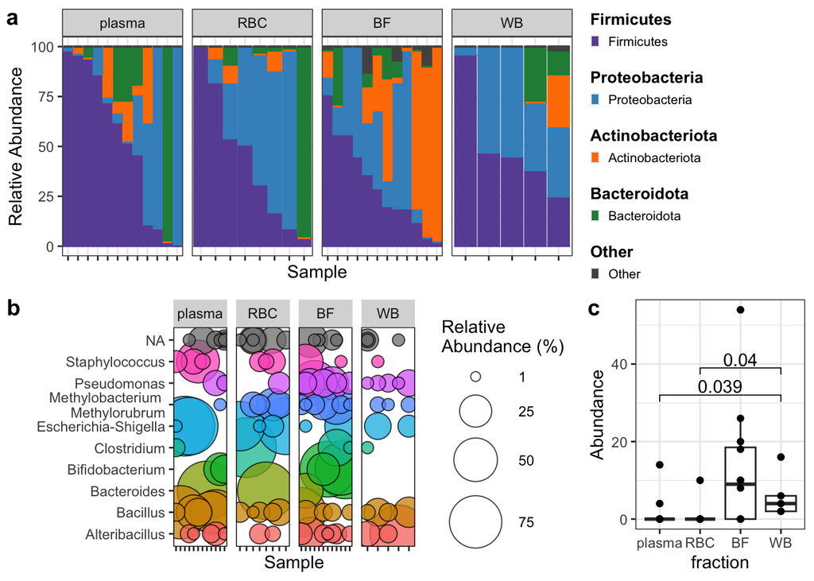

```r
bottom_row <- plot_grid(Fig3b, Fig3C, labels = c("b", "c"), rel_widths = c(2.5, 1))

plot_grid(Fig3a_opt2, bottom_row, labels = c("a", ""), ncol = 1)
```

# Clean-up

```r
keep <- c("ps_r50", "meta_ps", "ps")
rm(list=setdiff(ls(), keep))
```